# Dice Experiment

## Simulation Study of Dice Rolls Sums Experiment

Lets consider this Dice Roll Summation experiment. We will perform the experiment 100000 times, and see what sort of distribution of summations we get. We will save the results in a vector called `sums`.

```r
Dice = 1:6
Sums=numeric()    # Initialize An Empty Vector
M=100000  # Number of Iterations

for (i in 1:M)
    {
     NewSum=sum(sample(Dice,100,replace=TRUE))
     Sums = c(Sums, NewSum)
     }
```

```r
length(Sums[Sums<300])
```

```
## [1] 147
```

```r
length(Sums[Sums>400])
```

```
## [1] 146
```

Lets us look at a histogram (a type of bar chart) of the `sums` vector ( Use around breaks =100 to specify more intervals). What sort of shape is this histogram?

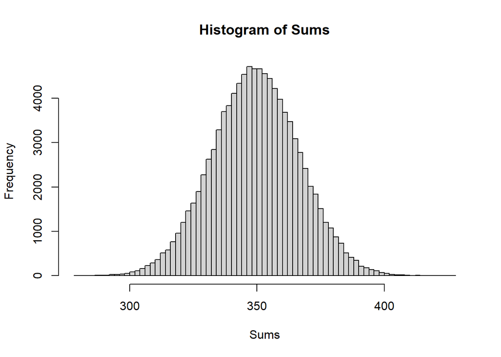

```r
hist(Sums, breaks=100)
```

### Central Limit Theorem

This is a very crude introduction to the Central Limit Theorem. Even though the Dice Rolls are not normally distributed, the distribution of summations, are described in this experiment, are from a normally distributed sampling population. Also consider the probability of getting a sum more than 400.

Suppose it was not certain whether a die was fair or crooked favouring higher values such as 4,5 and 6. The 100 roll experiment was performed and the score turned out to be 400. It would be a very unusual outcome for a fair die, but not impossible. For crooked dice, larger summations would be expected and a score of approximately 400 would be common. Would you think the die was fair or crooked.

Footnote: Arbitrarily, let us consider a crooked dice, where 4,5 and 6 are twice a likely to appear. Try out the following code.

```r
CrookedDice=c(1,2,3,4,4,5,5,6,6)
sum(sample(CrookedDice,100,replace=TRUE))
```

```
## [1] 362
```